# Comfort Homework 11 Live Session

Chayson Comfort

7/30/2017

## Introduction

The analysis presented in this file is from the Homeowrk that was presented to the class this past week with an expected sudmission date of 7/31/17. The SNP500 data is a series of data from the S&P 500. Some of the data is volatile, some is less volatile. This docuement describes the methods of downloading the data, calculating the log returns, calculating volatility measure, doing the same over an entire length of series for various three different decay factors. I then plotted the results overlaying the volatility curves on the data.

## Code

All coding for this analysis was created using R Studio to create R Script files. A single R Make-like file named “Makefile.R” was created to execute the data import, cleansing and analysis processes.

### Libraries

In addition to the base R libraries and packages, “tseries” was loaded to assist with the analysis.

```r
  install.packages("tseries", repos = "http://cran.us.r-project.org")
  library(tseries)
  install.packages("readr", repos = "http://cran.us.r-project.org")
  library(readr)
```

### Calculate Volatility Measure

```r
# Calculate volatility over entire length of series for various three different decay factors
SNPdata <- get.hist.quote('^gspc',quote="Close")
```

[output not shown]

[output not shown]

```
## time series ends   2017-07-28
```

```r
SNPret <- log(lag(SNPdata)) - log(SNPdata)
SNPvol <- sd(SNPret) * sqrt(250) * 100
```

```r
# Calculate Volatility
Vol <- function(d, logrets)
{ var = 0
    lam = 0
    varlist <- c()
    for (r in logrets)
{ lam = lam*(1 - 1/d) + 1
    var = (1 - 1/lam)*var + (1/lam)*r^2
  varlist <- c(varlist, var) }
    sqrt(varlist)
}
```

### Plot the results, overlaying the volatility curves on the data, just as was done in the S&P example

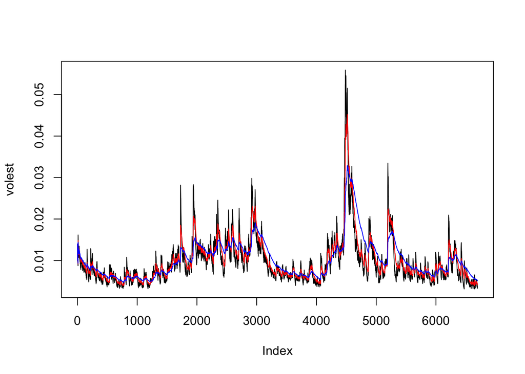

```r
volest <- Vol(10,SNPret)
volest2 <- Vol(30,SNPret)
volest3 <- Vol(100,SNPret)
plot(volest,type="l")
lines(volest2,type="l",col="red")
lines(volest3, type = "l", col="blue")
```